# Chapter 1

R for physicians

2025-11-23

| Author |  |
| --- | --- |
| Name | Claire Descombes |
| Affiliation | Universitätsklinik für Neurochirurgie, Inselspital Bern |
| Degree | MSc Statistics and Data Science, University of Bern |
| Contact | claire.descombes@insel.ch |

The reference material for this course, as well as some useful literature to deepen your knowledge of R, can be found at the bottom of the page.

# 1 User interface

**R** is a free and open source statistical computing and graphics software.

**RStudio** is a user-friendly environment for R, designed to facilitate its accessibility. R can technically be used without RStudio (although I wouldn’t advise it), but the reverse is not possible. To download both, follow the links below:

- [**Download R**](https://stat.ethz.ch/CRAN/)
- [**Download RStudio**](https://posit.co/download/rstudio-desktop/)

✏️ Download both softwares.

Once you have downloaded both programs and opened RStudio, you will be presented with a window similar to the one shown in the following figure.

[figure not shown]

- Left pane: Contains the Console, Terminal and Background Jobs tabs.
- Top right pane: contains the Environment, History, Connections and Tutorial tabs.
- Bottom right pane: contains the Files, Plots, Packages, Help, Viewer and Presentation tabs.

## 1.1 Console

In the **Console tab**, we first see information about the version of R we are using and some basic commands to try out. At the end of these descriptions, we can type our R code.

```r
2+2
```

```
## [1] 4
```

💡 To run a line in the Console, just type Enter.

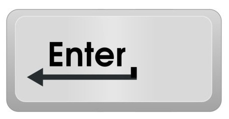

**Important** to note from now on: all the code you see in grey fields, such as this `2+2`, corresponds to code that can be run to produce a result, for example in the console. The code that appears in the white field following `##` is the output that you get in the console when you run that code.

## 1.2 Help

The `help()` function and `?` help operator in R provide access to the documentation pages for R functions, data sets, and other objects, both for packages in the standard R distribution and for contributed packages.

You can access help directly from the console or via the Help tab in the bottom right-hand corner.

```r
help(c)
# or equivalently
? c
```

## 1.3 Script file

However, when we run our code directly in the console, it isn’t saved for being reproduced further. If we need (and we usually do) to write a reproducible code to solve a specific task, we have to record and regularly save it in a **script file** rather than in the console.

To start recording a script, click *File – New File – R Script*. This will open a text editor in the top-left corner of the RStudio interface (above the Console tab, see following figure).

[figure not shown]

💡 To run a line in a Script file, first put your cursor on the line you want to run, and then you have two options:

- you can click on the `run` button at the top of the upper left panel,
- or you can simply type Ctrl + Enter.

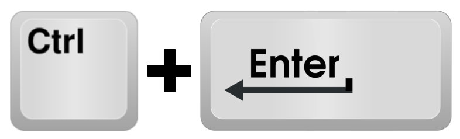

💡 When your code starts to get long or complex, consider breaking it down into separate scripts with clear and specific purposes — for example: `1_data_import.R`, `2_data_cleaning.R`, `3_survival_analysis.R`, `4_qol_analysis.R`, etc.

## 1.4 Comments

Comments can be added to the code in a script using the hash symbol `#`.

```r
# Here is a comment.
```

It is very, very important that you always comment every piece of your code, to make sure:

- that you will still be able to understand what you have written after a few months/years.
- to facilitate sharing: without comments, it will take someone much longer to understand your code.

So, for scientific purposes, **please comment your code**!  
Here’s an example of how I usually comment the scripts I use in my daily work:

```r
################################
# TOSCAN 2.0: Matching algorithm
################################

# 1) Script info-header --------------------------------------------------------

# Project:                  TOSCAN 2.0
# Author:                   Claire Descombes
# Contact:                  claire.descombes@insel.ch
# Date last modification:   07/05/2025
# Purpose:                  Match TOSCAN cohort to Swiss population using BFS data
# Environment:              R version 4.4.2
#                           RStudio 2024.09.1+394 "Cranberry Hibiscus" Release

# 2) Packages & environment ----------------------------------------------------

library(duckdb)      # Interface to DuckDB, an in-process SQL OLAP database engine for fast queries on large datasets
library(dplyr)       # Grammar of data manipulation for data frames (select, filter, mutate, etc.)
library(lubridate)   # Makes working with dates and times easier (e.g., extracting year, month, parsing dates)
library(arrow)       # Provides access to Apache Arrow tools, including reading/writing Parquet files
library(readxl)      # Imports Excel files (.xls and .xlsx) into R
library(progress)    # Adds progress bars to loops and long operations in the console
library(glue)        # Facilitates string interpolation, especially useful for building SQL queries dynamically

options(scipen = 999)  # Prevents scientific notation (e.g., 1e+05) when printing numbers

# 3) Data import ---------------------------------------------------------------

# Set working directory to source file location
setwd("C:/Users/I0343303/Documents/Forschung/TOSCAN2.0")

# Etc.
```

💡 Use `----` after numbered headers in comments to make your code more navigable and readable in long scripts (this is a common R style convention).

[figure not shown]

## 1.5 Exercises

### 1.5.1 Exercise 1

✏️ Exercise 1: Create your own script. Feel free to take notes directly in it. You’ll use this script as a working document to complete various small tasks and exercises.

☑️ All exercises have an example solution at the end of the chapter.

# 2 Objects, data types, variables

In R, everything is an **object**. This means that every piece of data you work with, from a single number to a complex dataset, is represented as an object with specific properties and behaviours. An object has attributes like class (**data type**) and dimensions.

**Variables** act as labels for objects. They are essentially pointers to the actual object stored in memory and appear in the Environment tab in RStudio.

Here’s an example to clarify the difference between variables and objects.

```r
# We create an object (here: a vector) named 'vec' and assign a sequence of numbers to it.

vec <- 1:10 # Defines the object
vec # Displays the object
```

```
##  [1]  1  2  3  4  5  6  7  8  9 10
```

```r
# 'vec' is the variable. The sequence of numbers (1, 2, 3, ..., 10) is the object.
```

💡 To assign values to an object, use the `<-` or `=` symbols.

## 2.1 Inspect an object

Before diving into data types and structures, it’s helpful to know how to inspect objects in R. Several built-in functions can help you understand the structure and content of an object.

Let’s define a simple data frame (more details about data frames below) to demonstrate the purpose of those functions.

```r
# Example data frame
df <- data.frame(
  ID = 1:5,
  Name = c("Anna", "Ben", "Carla", "David", "Eva"),
  Age = c(23, 31, 29, 40, 35)
)

# Let us display that data frame
df
```

| ID | Name | Age |
| --- | --- | --- |
| 1 | Anna | 23 |
| 2 | Ben | 31 |
| 3 | Carla | 29 |
| 4 | David | 40 |
| 5 | Eva | 35 |

Now let’s inspect thus object using a few useful functions.

```r
# General object inspection
typeof(df)          # Returns the internal storage type of the object
```

```
## [1] "list"
```

```r
str(df)             # Gives a compact, human-readable summary of the object's structure
```

```
## 'data.frame':    5 obs. of  3 variables:
##  $ ID  : int  1 2 3 4 5
##  $ Name: chr  "Anna" "Ben" "Carla" "David" ...
##  $ Age : num  23 31 29 40 35
```

```r
attributes(df)      # Lists the object's attributes (e.g., names, dimensions, class)
```

```
## $names
## [1] "ID"   "Name" "Age"
##
## $class
## [1] "data.frame"
##
## $row.names
## [1] 1 2 3 4 5
```

```r
str(attributes(df)) # Displays the structure of the attributes
```

```
## List of 3
##  $ names    : chr [1:3] "ID" "Name" "Age"
##  $ class    : chr "data.frame"
##  $ row.names: int [1:5] 1 2 3 4 5
```

```r
class(df)           # Returns the class of the object (e.g., data.frame)
```

```
## [1] "data.frame"
```

```r
# Functions especially useful for matrices or data frames
nrow(df)          # Number of rows
```

```
## [1] 5
```

```r
ncol(df)          # Number of columns
```

```
## [1] 3
```

```r
dim(df)           # Dimensions (rows, columns)
```

```
## [1] 5 3
```

```r
colnames(df)      # Column names
```

```
## [1] "ID"   "Name" "Age"
```

```r
rownames(df)      # Row names
```

```
## [1] "1" "2" "3" "4" "5"
```

```r
str(colnames(df)) # Structure of the column names (e.g., character vector)
```

```
##  chr [1:3] "ID" "Name" "Age"
```

```r
str(rownames(df)) # Structure of the row names (e.g., character vector)
```

```
##  chr [1:5] "1" "2" "3" "4" "5"
```

💡 The function `str()` provides a compact view of the internal structure of an R object, helping you understand its components and data types quickly.

## 2.2 Data types

In R, data types define the kind of information a variable can hold. Here are some of the most common data types:

### 2.2.1 Numeric

Represents real numbers (e.g., 3.14, -2.5, 0).

```r
str(3.14)
```

```
##  num 3.14
```

### 2.2.2 Integer

Represents whole numbers (e.g., 2L, -5L). The “L” suffix indicates an integer.

```r
str(2L)
```

```
##  int 2
```

### 2.2.3 Logical

Represents Boolean values (`TRUE` or `FALSE`).

```r
str(TRUE)
```

```
##  logi TRUE
```

```r
# Example of a logical operation
values <- 1:10
values > 5
```

```
##  [1] FALSE FALSE FALSE FALSE FALSE  TRUE  TRUE  TRUE  TRUE  TRUE
```

### 2.2.4 Character

Represents text or strings (e.g., “hello”, “world”).

```r
str("hello")
```

```
##  chr "hello"
```

### 2.2.5 Complex

Represents complex numbers (e.g., 1 + 2i).

```r
str(1 + 2i)
```

```
##  cplx 1+2i
```

### 2.2.6 NAs/NANs

In some cases the components of a vector may not be known. When an element or value is “not available” or a “missing value” in the statistical sense, a place within a vector may be reserved for it by assigning it the special value `NA`. In general any operation on an NA becomes an NA.

```r
z <- c(1:3,NA)
z
```

```
## [1]  1  2  3 NA
```

```r
is.na(z)
```

```
## [1] FALSE FALSE FALSE  TRUE
```

There is a second kind of “missing” values which are produced by numerical computation, the so-called “Not a Number”, `NaN`, values.

```r
0/0
```

```
## [1] NaN
```

```r
Inf - Inf
```

```
## [1] NaN
```

## 2.3 Objects

Objects are the entities that R operates on. These can be:

### 2.3.1 Vectors

- The most fundamental data structure.
- A one-dimensional array of elements of the same data type (e.g., numeric, character, logical).
- Created using e.g. the `c()` function.

```r
vec1 <- c(1,2,3)
str(vec1)
```

```
##  num [1:3] 1 2 3
```

```r
# Alternative ways of creating vectors:
vec2 <- 1:3  # Sequence of integers
vec3 <- seq(1, 3, by=1)  # More general sequence
```

Vector elements can be accessed using `[]` brackets.

💡 Note that R uses 1-based indexing, meaning that the first element of a vector is denoted with the index 1 (unlike other programming language, like Python, which start at 0).

```r
# Accessing elements of the vector by index
(vec <- seq(10, 15, by=1))
```

```
## [1] 10 11 12 13 14 15
```

```r
# Access element
vec[1]  # First element
```

```
## [1] 10
```

```r
vec[c(2, 3)]  # Elements at indices 2 and 3
```

```
## [1] 11 12
```

```r
vec[-2]  # All elements except for the element at index 2
```

```
## [1] 10 12 13 14 15
```

```r
vec[length(vec)]  # Last element
```

```
## [1] 15
```

💡 Use `length()` to get the length of vectors.

💡 By **enclosing the assignment in parentheses** `()`, you not only create/define the object but also automatically print its value to the console: a useful shortcut. This is equivalent to writing `print(object)` or simply typing the object name (e.g., `object`), but it saves you an extra line of code.

### 2.3.2 Matrices

- Two-dimensional arrays of elements of the same data type.
- Can be created using the `matrix()` function.

```r
(mat <- matrix(c(1,2,3,4), nrow = 2, ncol = 2))
```

```
##      [,1] [,2]
## [1,]    1    3
## [2,]    2    4
```

```r
str(mat)
```

```
##  num [1:2, 1:2] 1 2 3 4
```

```r
# Access element
mat[1,2]
```

```
## [1] 3
```

Matrices elements can be accessed using `[,]` brackets, but with two indices this time: one for the row, one for the column!

### 2.3.3 Arrays

- Generalization of matrices to more than two dimensions.

```r
(array <- array(1:8, c(2,4,2)))
```

```
## , , 1
##
##      [,1] [,2] [,3] [,4]
## [1,]    1    3    5    7
## [2,]    2    4    6    8
##
## , , 2
##
##      [,1] [,2] [,3] [,4]
## [1,]    1    3    5    7
## [2,]    2    4    6    8
```

```r
str(array)
```

```
##  int [1:2, 1:4, 1:2] 1 2 3 4 5 6 7 8 1 2 ...
```

### 2.3.4 Lists

- Ordered collections of objects, which may be of different types.
- Lists can contain other lists as elements.

```r
(list <- list(numb = 10:15, char = 'hello'))
```

```
## $numb
## [1] 10 11 12 13 14 15
##
## $char
## [1] "hello"
```

```r
str(list)
```

```
## List of 2
##  $ numb: int [1:6] 10 11 12 13 14 15
##  $ char: chr "hello"
```

### 2.3.5 Factors

- Categorical variables.
- Represent data with a limited number of possible values.

```r
(fac <- factor(c("single", "married")))
```

```
## [1] single  married
## Levels: married single
```

```r
str(fac)
```

```
##  Factor w/ 2 levels "married","single": 2 1
```

### 2.3.6 Data frames

- Two-dimensional tabular data structure.
- Can contain columns of different data types, such as numeric, character, logical, or factor.
- The most common data structure for representing datasets in R.
- Technically, a data frame is a special type of list where each element (i.e., column) is of the same length and can be a vector (numeric, character, logical), factor, matrix, list, or even another data frame.

```r
(d <- data.frame(id = 1:5,
                 val = c(4,5,2,6,5),
                 group = sample(c("exp","control"), size = 5, replace = TRUE)))
```

| id | val | group |
| --- | --- | --- |
| 1 | 4 | exp |
| 2 | 5 | exp |
| 3 | 2 | control |
| 4 | 6 | exp |
| 5 | 5 | exp |

```r
str(d)
```

```
## 'data.frame':    5 obs. of  3 variables:
##  $ id   : int  1 2 3 4 5
##  $ val  : num  4 5 2 6 5
##  $ group: chr  "exp" "exp" "control" "exp" ...
```

```r
# Access element
d$group
```

```
## [1] "exp"     "exp"     "control" "exp"     "exp"
```

```r
d[3,2]
```

```
## [1] 2
```

Data frame columns can be accessed using `$` symbol.

Data frame elements can be accessed using `[,]` brackets, but with two indices like for matrices: one for the row, one for the column!

### 2.3.7 Functions

- Reusable blocks of code that perform a specific task.
- Also considered objects in R.

```r
frac <- function(numerator, denominator) {
  result <- numerator / denominator
  return(result)
}

frac(numerator = 6, denominator = 2) # Calling the function
```

```
## [1] 3
```

💡 A function takes inputs called arguments. These can be:

- *Explicitly specified*, e.g., `frac(numerator = 6, denominator = 2)`, or
- *Implicitly given in order*, e.g., `frac(6, 2)`.

I strongly recommend explicitly naming arguments, because it increases clarity, prevents order-related mistakes, and gives you flexibility in argument order: `frac(denominator = 2, numerator = 6)` works just as well. In contrast, when arguments are unnamed, order matters strictly — and a small mistake can completely change the result: `frac(2, 6)` is interpreted as `frac(numerator = 2, denominator = 6)`!

Also, a function sometimes has arguments which have a **default value**, meaning that the function can still run even if you do not give a value for those arguments, the function will simply use the defaults values instead. An example: when you look in the documentation for the function `rnorm()` (e.g. by running `help(rnorm)`), you find this expression:

```
rnorm(n, mean = 0, sd = 1)
```

The description tells us: “Random generation for the normal distribution with mean equal to mean and standard deviation equal to sd.” As we can see, the arguments `mean` and `sd` have default values, namely `0` and `1`. So if you do not tell the function otherwise, and simply run `rnorm(n = 10)`, you will get 10 numbers following a *standard* normal distribution, but if you run `rnorm(n = 10, mean = 2, sd = 0.5)`, you can generate number following a normal distribution with location and shape of your choice!

## 2.4 Why data types matter

💡 Before every analysis, always check that your variables have the correct data type!

When importing data, R sometimes guesses the wrong type (numeric instead of categorical, character instead of factor, etc.). This can completely change the results of your analysis, especially for regression models.

Here is a simple example:

```r
# Imagine a data set with 3 groups: control, treatment 1, treatment 2, coded
# initially as 1, 2, and 3
df <- data.frame(
  Group = c(1, 2, 3, 2, 3),
  BP_systolic = c(129, 135, 110, 124, 128)  # avoid spaces in column names
)

# Look at the data
df
```

| Group | BP_systolic |
| --- | --- |
| 1 | 129 |
| 2 | 135 |
| 3 | 110 |
| 2 | 124 |
| 3 | 128 |

```r
# Check the data type of "Group"
str(df$Group)
```

```
##  num [1:5] 1 2 3 2 3
```

```r
# --> R treats "Group" as numeric!
# If you used this variable in a regression, the model would assume a numeric
# order (control < treatment 1 < treatment 2), which is wrong.

# Correct: convert "Group" to a factor
df$Group <- as.factor(df$Group)
str(df$Group)
```

```
##  Factor w/ 3 levels "1","2","3": 1 2 3 2 3
```

## 2.5 Exercises

### 2.5.1 Exercise 2

✏️ Exercise 2: Given a vector of ages (`ages <- c(35, 45, 60, 15, 50, 8)`), determine which patients are eligible for a treatment (age above 18). Return a Boolean vector indicating whether each patient meets the age criteria (something like `TRUE, TRUE, TRUE, FALSE, TRUE, FALSE`). Then use this Boolean vector to create a second vector of ages containing only the ages above 18.

### 2.5.2 Exercise 3

✏️ Exercise 3: Create a data frame with 10 rows and the columns `id`, `blood_pressure`, and `group`.

– `id`: integers from 1 to 10

– `blood_pressure`: random values from a normal distribution with mean 123 and standard deviation 8

– `group`: a factor with levels “drug 1”, “drug 2”, and “obs arm” (you decide how to assign them, e.g. by using the function `sample()`)

After creating that data frame, add a new column `stand_score` where you calculate a standardized score for each blood_pressure value. The standardized score is calculated based on the mean and standard deviation of the `blood_pressure` values in the dataset (standardized score = $(x−\mu)/\sigma$).

💡 Hint: Use the function `rnorm()` to simulate normal values. Use the function `scale()` to centre and scale a vector, or alternatively the functions `mean()` and `sd()` to compute mean and standard deviation of a vector. You can use `help()` to learn more about how these functions work.

### 2.5.3 Exercise 4

✏️ Exercise 4: Write a function `sum_squared` that takes two integers and returns the sum of their squared values.

```r
# Example
sum_squared(int1 = 2, int2 = 3)
# The output should be:
13
```

# 3 Packages

**Packages** are collections of R functions, data, and compiled code in a well-defined format, created to add specific functionality.

There is a set of standard (or base) packages which are considered part of the R source code and automatically available as part of your R installation. **Base packages** contain the basic functions that allow R to work, and enable standard statistical and graphical functions on datasets.

On top of that, there are 10,000+ **user contributed packages**. You can install packages using the ``install.packages()` function.

```r
# To install a package, you can use the function.
install.packages("dplyr")

# Alternatively, you can click on 'Packages' in the bottom right pane, then
# click on 'Install' and type in the name of the package you want to install.

# To load a package you've already install, just load it using the library() function.
library(dplyr)
```

💡 On institutional laptops, package installation may be blocked by your institution’s firewall. This is something you cannot disable yourself. If you experience problems installing R packages, try switching from your work network to a private network (e.g. home Wi-Fi or mobile hotspot). Also make sure that your institution’s VPN is disconnected, otherwise the firewall restrictions will still apply.

## 3.1 Exercises

### 3.1.1 Exercise 5

✏️ Exercise 5: install and load the `tidyverse` package. We will need it for Chapter 2.

# 4 Solutions to the exercises

Please note that those are only examples, there are always many ways to solve the same task!

## 4.1 Exercise 1

☑️ Exercise 1:

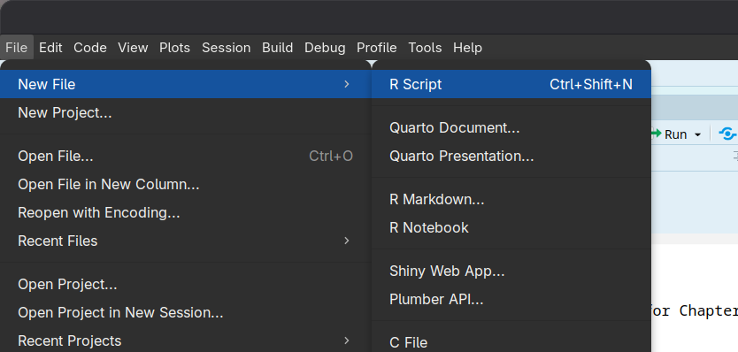

## 4.2 Exercise 2

☑️ Exercise 2:

```r
# We first define the ages vector
(ages <- c(35, 45, 60, 15, 50, 8))
```

```
## [1] 35 45 60 15 50  8
```

```r
# Now we check, through a logical operation, which are above 18
ages >= 18
```

```
## [1]  TRUE  TRUE  TRUE FALSE  TRUE FALSE
```

```r
# Or equivalently
ages > 17
```

```
## [1]  TRUE  TRUE  TRUE FALSE  TRUE FALSE
```

```r
# Now we store this Boolean vector
eligible <- ages >= 18
# And select only the entries of 'ages' which are above 18
(ages_above_18 <- ages[eligible])
```

```
## [1] 35 45 60 50
```

## 4.3 Exercise 3

☑️ Exercise 3:

```r
# Create the data frame
(df <- data.frame(id = 1:10,
                 blood_pressure = rnorm(10, mean = 123, sd = 8),
                 group = factor(sample(c("drug 1", "drug 2", "obs arm"), 10, replace = TRUE))))
```

| id | blood_pressure | group |
| --- | --- | --- |
| 1 | 124.1778 | drug 2 |
| 2 | 136.3750 | obs arm |
| 3 | 124.0460 | obs arm |
| 4 | 120.3677 | drug 1 |
| 5 | 131.7639 | drug 1 |
| 6 | 126.4186 | obs arm |
| 7 | 115.9606 | obs arm |
| 8 | 118.3320 | obs arm |
| 9 | 131.6478 | drug 2 |
| 10 | 118.9310 | drug 2 |

```r
# Compute standardized scores for blood pressure
df$stand_score <- scale(df$blood_pressure)

# Alternatively, compute by hand (standardized score = (x - μ) / σ)
df$stand_score_2 <- (df$blood_pressure - mean(df$blood_pressure))/sd(df$blood_pressure)

# View the data frame with standardized scores
df
```

| id | blood_pressure | group | stand_score | stand_score_2 |
| --- | --- | --- | --- | --- |
| 1 | 124.1778 | drug 2 | -0.09282245 | -0.09282245 |
| 2 | 136.3750 | obs arm | 1.72093771 | 1.72093771 |
| 3 | 124.0460 | obs arm | -0.11243070 | -0.11243070 |
| 4 | 120.3677 | drug 1 | -0.65940085 | -0.65940085 |
| 5 | 131.7639 | drug 1 | 1.03525375 | 1.03525375 |
| 6 | 126.4186 | obs arm | 0.24039225 | 0.24039225 |
| 7 | 115.9606 | obs arm | -1.31475181 | -1.31475181 |
| 8 | 118.3320 | obs arm | -0.96211516 | -0.96211516 |
| 9 | 131.6478 | drug 2 | 1.01799154 | 1.01799154 |
| 10 | 118.9310 | drug 2 | -0.87305428 | -0.87305428 |

## 4.4 Exercise 4

☑️ Exercise 4:

```r
sum_squared <- function(int1, int2){
  sum_of_squares <- int1^2 + int2^2
  return(sum_of_squares)
}

sum_squared(int1 = 3, int2 = 5)
```

```
## [1] 34
```

## 4.5 Exercise 5

☑️ Exercise 5:

```r
# To install the package, run the line:
install.packages("tidyverse")

# To load the package once installed, run the line:
library(tidyverse)
```

# References

Alexander Henzi. 2021. “Programming and Data Analysis with R.” Lecture notes.

Burns, Patrick. n.d. *The R Inferno*. Accessed May 8, 2025. https://www.burns-stat.com/documents/books/the-r-inferno/.

CDC. 2025. “National Death Index.” *Data Linkage*. https://www.cdc.gov/nchs/linked-data/mortality-files/index.html.

“ChatGPT.” n.d. Accessed January 26, 2025. https://chatgpt.com.

Christopher J. Endres. 2025. “Introducing nhanesA.” https://cran.r-project.org/web/packages/nhanesA/vignettes/Introducing_nhanesA.html.

“Create Elegant Data Visualisations Using the Grammar of Graphics.” n.d. Accessed January 26, 2025. https://ggplot2.tidyverse.org/.

David, Author. 2016. “BIRT Joins.” *MBSE Chaos*. https://mbsechaos.wordpress.com/2016/05/24/birt-joins/.

Elena Kosourova. n.d. “RStudio Tutorial for Beginners: A Complete Guide.” Accessed January 26, 2025. https://www.datacamp.com/tutorial/r-studio-tutorial.

Ghasemi, Asghar, and Saleh Zahediasl. 2012. “Normality Tests for Statistical Analysis: A Guide for Non-Statisticians.” *International Journal of Endocrinology and Metabolism* 10 (2): 486–89. https://doi.org/10.5812/ijem.3505.

Grolemund, Hadley Wickham and Garrett. n.d. *R for Data Science*. Accessed May 8, 2025. https://r4ds.had.co.nz/introduction.html.

Mayer, Michael. 2025. “Mayer79/Statistical_computing_material.” https://github.com/mayer79/statistical_computing_material.

Patrick Burns. n.d. *Impatient R*. Accessed May 8, 2025. https://www.burns-stat.com/documents/tutorials/impatient-r/.

“*P*-Value.” 2025. *Wikipedia*. https://en.wikipedia.org/w/index.php?title=P-value&oldid=1305292611.

“Synthetic Dataset for AI in Healthcare.” n.d. Accessed May 9, 2025. https://www.kaggle.com/datasets/smmmmmmmmmmmm/synthetic-dataset-for-ai-in-healthcare.

“The Comprehensive R Archive Network.” n.d. Accessed January 26, 2025. https://stat.ethz.ch/CRAN/.

W. N. Venables, D. M. Smith and the R Core Team. n.d. “An Introduction to R.” Accessed May 8, 2025. https://cran.r-project.org/doc/manuals/r-release/R-intro.html.

Wickham, Hadley. n.d. *Advanced R*. Accessed May 8, 2025. https://adv-r.hadley.nz/introduction.html.